# GOLDHR

## Descriptive statistics

We show the descriptive statistics of the factors

|  | min | 25 percent | median | mean | 75 percent | max | std |
| --- | --- | --- | --- | --- | --- | --- | --- |
| satisfaction_level | 0.09 | 0.44 | 0.64 | 0.61 | 0.82 | 1 | 0.25 |
| last_evaluation | 0.36 | 0.56 | 0.72 | 0.72 | 0.87 | 1 | 0.17 |
| number_project | 2.00 | 3.00 | 4.00 | 3.80 | 5.00 | 7 | 1.23 |
| average_montly_hours | 96.00 | 156.00 | 200.00 | 201.05 | 245.00 | 310 | 49.94 |
| time_spend_company | 2.00 | 3.00 | 3.00 | 3.50 | 4.00 | 10 | 1.46 |
| Work_accident | 0.00 | 0.00 | 0.00 | 0.14 | 0.00 | 1 | 0.35 |
| left | 0.00 | 0.00 | 0.00 | 0.24 | 0.00 | 1 | 0.43 |
| promotion_last_5years | 0.00 | 0.00 | 0.00 | 0.02 | 0.00 | 1 | 0.14 |
| Salary | 0.00 | 0.00 | 1.00 | 0.59 | 1.00 | 2 | 0.64 |
| Sales | 0.00 | 0.00 | 0.00 | 0.28 | 1.00 | 1 | 0.45 |
| Accounting | 0.00 | 0.00 | 0.00 | 0.05 | 0.00 | 1 | 0.22 |
| Hr | 0.00 | 0.00 | 0.00 | 0.05 | 0.00 | 1 | 0.22 |
| product_mng | 0.00 | 0.00 | 0.00 | 0.06 | 0.00 | 1 | 0.24 |
| technical | 0.00 | 0.00 | 0.00 | 0.18 | 0.00 | 1 | 0.39 |
| support | 0.00 | 0.00 | 0.00 | 0.15 | 0.00 | 1 | 0.36 |
| IT | 0.00 | 0.00 | 0.00 | 0.08 | 0.00 | 1 | 0.27 |
| RandD | 0.00 | 0.00 | 0.00 | 0.05 | 0.00 | 1 | 0.22 |

We need to scale the data (excluding dummy variables)

Notice now the summary statistics of the scaled dataset (excluding dummy variables for the department):

|  | min | 25 percent | median | mean | 75 percent | max | std |
| --- | --- | --- | --- | --- | --- | --- | --- |
| satisfaction_level | -2.10 | -0.70 | 0.11 | 0 | 0.83 | 1.56 | 1 |
| last_evaluation | -2.08 | -0.91 | 0.02 | 0 | 0.90 | 1.66 | 1 |
| number_project | -1.46 | -0.65 | 0.16 | 0 | 0.97 | 2.59 | 1 |
| average_montly_hours | -2.10 | -0.90 | -0.02 | 0 | 0.88 | 2.18 | 1 |
| time_spend_company | -1.03 | -0.34 | -0.34 | 0 | 0.34 | 4.45 | 1 |
| Work_accident | -0.41 | -0.41 | -0.41 | 0 | -0.41 | 2.43 | 1 |
| left | -0.56 | -0.56 | -0.56 | 0 | -0.56 | 1.79 | 1 |
| promotion_last_5years | -0.15 | -0.15 | -0.15 | 0 | -0.15 | 6.78 | 1 |
| Salary | -0.93 | -0.93 | 0.64 | 0 | 0.64 | 2.21 | 1 |

Let’s see how these are correlated. The correlation matrix is as follows:

|  | satisfaction_level | last_evaluation | number_project | average_montly_hours | time_spend_company | Work_accident | left | promotion_last_5years | Salary | Sales | Accounting | Hr | product_mng | technical | support | IT | RandD |
| --- | --- | --- | --- | --- | --- | --- | --- | --- | --- | --- | --- | --- | --- | --- | --- | --- | --- |
| satisfaction_level | 1.00 | 0.11 | -0.14 | -0.02 | -0.10 | 0.06 | -0.39 | 0.03 | 0.05 | 0.00 | -0.03 | -0.01 | 0.01 | -0.01 | 0.01 | 0.01 | 0.01 |
| last_evaluation | 0.11 | 1.00 | 0.35 | 0.34 | 0.13 | -0.01 | 0.01 | -0.01 | -0.01 | -0.02 | 0.00 | -0.01 | 0.00 | 0.01 | 0.02 | 0.00 | -0.01 |
| number_project | -0.14 | 0.35 | 1.00 | 0.42 | 0.20 | 0.00 | 0.02 | -0.01 | 0.00 | -0.01 | 0.00 | -0.03 | 0.00 | 0.03 | 0.00 | 0.00 | 0.01 |
| average_montly_hours | -0.02 | 0.34 | 0.42 | 1.00 | 0.13 | -0.01 | 0.07 | 0.00 | 0.00 | 0.00 | 0.00 | -0.01 | -0.01 | 0.01 | 0.00 | 0.01 | 0.00 |
| time_spend_company | -0.10 | 0.13 | 0.20 | 0.13 | 1.00 | 0.00 | 0.14 | 0.07 | 0.05 | 0.02 | 0.00 | -0.02 | 0.00 | -0.03 | -0.03 | -0.01 | -0.02 |
| Work_accident | 0.06 | -0.01 | 0.00 | -0.01 | 0.00 | 1.00 | -0.15 | 0.04 | 0.01 | 0.00 | -0.01 | -0.02 | 0.00 | -0.01 | 0.01 | -0.01 | 0.02 |
| left | -0.39 | 0.01 | 0.02 | 0.07 | 0.14 | -0.15 | 1.00 | -0.06 | -0.16 | 0.01 | 0.02 | 0.03 | -0.01 | 0.02 | 0.01 | -0.01 | -0.05 |
| promotion_last_5years | 0.03 | -0.01 | -0.01 | 0.00 | 0.07 | 0.04 | -0.06 | 1.00 | 0.10 | 0.01 | 0.00 | 0.00 | -0.04 | -0.04 | -0.04 | -0.04 | 0.02 |
| Salary | 0.05 | -0.01 | 0.00 | 0.00 | 0.05 | 0.01 | -0.16 | 0.10 | 1.00 | -0.04 | 0.01 | 0.00 | -0.01 | -0.02 | -0.03 | -0.01 | 0.00 |
| Sales | 0.00 | -0.02 | -0.01 | 0.00 | 0.02 | 0.00 | 0.01 | 0.01 | -0.04 | 1.00 | -0.14 | -0.14 | -0.16 | -0.29 | -0.26 | -0.18 | -0.15 |
| Accounting | -0.03 | 0.00 | 0.00 | 0.00 | 0.00 | -0.01 | 0.02 | 0.00 | 0.01 | -0.14 | 1.00 | -0.05 | -0.06 | -0.11 | -0.10 | -0.07 | -0.05 |
| Hr | -0.01 | -0.01 | -0.03 | -0.01 | -0.02 | -0.02 | 0.03 | 0.00 | 0.00 | -0.14 | -0.05 | 1.00 | -0.06 | -0.11 | -0.10 | -0.07 | -0.05 |
| product_mng | 0.01 | 0.00 | 0.00 | -0.01 | 0.00 | 0.00 | -0.01 | -0.04 | -0.01 | -0.16 | -0.06 | -0.06 | 1.00 | -0.12 | -0.11 | -0.08 | -0.06 |
| technical | -0.01 | 0.01 | 0.03 | 0.01 | -0.03 | -0.01 | 0.02 | -0.04 | -0.02 | -0.29 | -0.11 | -0.11 | -0.12 | 1.00 | -0.20 | -0.14 | -0.11 |
| support | 0.01 | 0.02 | 0.00 | 0.00 | -0.03 | 0.01 | 0.01 | -0.04 | -0.03 | -0.26 | -0.10 | -0.10 | -0.11 | -0.20 | 1.00 | -0.12 | -0.10 |
| IT | 0.01 | 0.00 | 0.00 | 0.01 | -0.01 | -0.01 | -0.01 | -0.04 | -0.01 | -0.18 | -0.07 | -0.07 | -0.08 | -0.14 | -0.12 | 1.00 | -0.07 |
| RandD | 0.01 | -0.01 | 0.01 | 0.00 | -0.02 | 0.02 | -0.05 | 0.02 | 0.00 | -0.15 | -0.05 | -0.05 | -0.06 | -0.11 | -0.10 | -0.07 | 1.00 |

## Dimensionability reduction

```r
# Columns used
factor_attributes_used = c(1:17)

# Factor Selection Criteria, Choices: 'eigenvalue', 'variance', 'manual'
factor_selectionciterion = "manual"

# Please ENTER the desired minumum variance explained
minimum_variance_explained = 40  # between 1 and 100

# Please ENTER the number of factors to use
manual_numb_factors_used = 4

# Please ENTER the rotation eventually used (e.g. 'none', 'varimax',
# 'quatimax', 'promax', 'oblimin', 'simplimax', and 'cluster' - see
# help(principal)). Default is 'varimax'
rotation_used = "varimax"
```

# Define Database for Clustering and Segmentation

# Save the Inputs in Variables

# Eigenvalue and explained variance

|  | Eigenvalue | Pct of explained variance | Cumulative pct of explained variance |
| --- | --- | --- | --- |
| Component 1 | 1.83 | 22.88 | 22.88 |
| Component 2 | 1.13 | 14.15 | 37.03 |
| Component 3 | 1.04 | 12.99 | 50.02 |
| Component 4 | 1.00 | 12.48 | 62.50 |
| Component 5 | 0.98 | 12.22 | 74.72 |
| Component 6 | 0.84 | 10.55 | 85.26 |
| Component 7 | 0.63 | 7.89 | 93.15 |
| Component 8 | 0.55 | 6.85 | 100.00 |

[interactive chart not shown]

# See top factors and rotate

|  | Comp.1 | Comp.2 | Comp.3 | Comp.4 |
| --- | --- | --- | --- | --- |
| last_evaluation | 0.76 | 0.21 | -0.01 | -0.02 |
| average_montly_hours | 0.76 | -0.04 | -0.03 | -0.01 |
| number_project | 0.74 | -0.28 | 0.02 | -0.01 |
| time_spend_company | 0.29 | -0.51 | 0.37 | 0.19 |
| satisfaction_level | 0.07 | 0.85 | 0.12 | 0.08 |
| Work_accident | -0.01 | 0.22 | 0.41 | 0.53 |
| Sales | -0.04 | -0.10 | -0.25 | 0.82 |
| Salary | -0.06 | 0.00 | 0.82 | -0.13 |

We see that we do not need to perform the PCA, hence we will use all of the variables in our analysis

# Segmentation

```r
# Select Attributes to use
segmentation_attributes_used = c(2, 1, 9, 6)  #c(10,19,5,12,3)

# original raw attributes
profile_attributes_used = c(1:17)

# Please ENTER the number of clusters to eventually use for this report
numb_clusters_used = 5  # for boats possibly use 5, for Mall_Visits use 3

# Please enter the method to use for the segmentation:
profile_with = "kmeans"


# Please ENTER the distance metric eventually used for the clustering in
# case of hierarchical clustering (e.g. 'euclidean', 'maximum', 'manhattan',
# 'canberra', 'binary' or 'minkowski' - see help(dist)).  DEFAULT is
# 'euclidean' distance_used = 'euclidean'


# Please ENTER the kmeans clustering method to use (options are:
# 'Hartigan-Wong', 'Lloyd', 'Forgy', 'MacQueen').  DEFAULT is 'Lloyd'
kmeans_method = "Lloyd"
```

First, we selected our segmentation attributes by taking the attributes that most resonate with each of the four components. Specifically, we used last_peformance (col. 2), satisfaction_level (1), Salary (9), and Work_accident (6) to represent components 1, 2, 3, and 4 respectively.  
Next, for profile_attributes_used, we included all the columns in the data set, per standard procedure.  
For the number of clusters used, we conducted a number of trials to arrive at the appropriate number of segments that were clearly distinct from each other. We started with 5, but noticed that while four clusters were highly differentiated, there was one segment that had no attributes that they strongly represented. Thus, we tried narrowing the clusters to 4 and 3. This did not help, as it simply removed differentiated clusters while keeping the non-differentiated one. We then tried extending it to 6 clusters, but all it did was made the other clusters less differentiated across the board. This is how we arrived at 5 as the optimal number of clusters.  
Finally, we used a Kmeans-Lloyd clustering method.

# Save selected criteria

```r
segmentation_attributes_used <- intersect(segmentation_attributes_used, 1:ncol(ProjectData_Clustering))
profile_attributes_used <- intersect(profile_attributes_used, 1:ncol(ProjectData_Clustering))

ProjectData_segment <- ProjectData_Clustering[, segmentation_attributes_used]
ProjectData_profile <- ProjectData_Clustering[, profile_attributes_used]

ProjectData_scaled <- apply(ProjectData_Clustering, 2, function(r) if (sd(r) !=
    0) (r - mean(r))/sd(r) else 0 * r)
```

This is the intermediary step that we undertook, assigning variables and tables for the exercises below.

# Apply kmeans to calculate clusters/segments

```r
kmeans_clusters <- kmeans(ProjectData_Clustering, centers = numb_clusters_used,
    iter.max = 2000, algorithm = kmeans_method)

ProjectData_with_kmeans_membership <- cbind(1:length(kmeans_clusters$cluster),
    kmeans_clusters$cluster)
colnames(ProjectData_with_kmeans_membership) <- c("Empl.Nr", "Cluster_Membership")

iprint.df(round(head(ProjectData_with_kmeans_membership, max_data_report), 2))
```

| Empl.Nr | Cluster_Membership |
| --- | --- |
| 1 | 1 |
| 2 | 2 |
| 3 | 3 |
| 4 | 4 |
| 5 | 1 |
| 6 | 1 |
| 7 | 3 |
| 8 | 4 |
| 9 | 4 |
| 10 | 1 |
| 11 | 1 |
| 12 | 3 |
| 13 | 4 |
| 14 | 1 |
| 15 | 1 |
| 16 | 1 |
| 17 | 1 |
| 18 | 4 |
| 19 | 1 |
| 20 | 4 |
| 21 | 3 |
| 22 | 1 |
| 23 | 3 |
| 24 | 1 |
| 25 | 1 |

# Segment comparison to mean

```r
cluster_memberships_kmeans <- kmeans_clusters$cluster
cluster_ids_kmeans <- unique(cluster_memberships_kmeans)

if (FALSE) {
    if (profile_with == "hclust") {
        cluster_memberships <- cluster_memberships_hclust
        cluster_ids <- cluster_ids_hclust
    }
    if (profile_with == "kmeans") {
        cluster_memberships <- cluster_memberships_kmeans
        cluster_ids <- cluster_ids_kmeans
    }
}

cluster_memberships <- cluster_memberships_kmeans
cluster_ids <- cluster_ids_kmeans

NewData = matrix(cluster_memberships, ncol = 1)

population_average = matrix(apply(ProjectData_profile, 2, mean), ncol = 1)
colnames(population_average) <- "Population"
Cluster_Profile_mean <- sapply(sort(cluster_ids), function(i) apply(ProjectData_profile[(cluster_memberships ==
    i), ], 2, mean))
if (ncol(ProjectData_profile) < 2) Cluster_Profile_mean = t(Cluster_Profile_mean)
colnames(Cluster_Profile_mean) <- paste("Seg.", 1:length(cluster_ids), sep = "")
cluster.profile <- cbind(population_average, Cluster_Profile_mean)

iprint.df(round(cluster.profile, 2))
```

|  | Population | Seg.1 | Seg.2 | Seg.3 | Seg.4 | Seg.5 |
| --- | --- | --- | --- | --- | --- | --- |
| satisfaction_level | 0.00 | -0.71 | 0.19 | -1.79 | 0.55 | 0.53 |
| last_evaluation | 0.00 | -0.97 | -0.04 | 0.56 | 1.01 | -0.59 |
| number_project | 0.00 | -1.06 | 0.03 | 1.52 | 0.10 | 0.02 |
| average_montly_hours | 0.00 | -1.05 | -0.05 | 0.99 | 0.23 | 0.11 |
| time_spend_company | 0.00 | -0.28 | 2.63 | 0.50 | -0.10 | -0.47 |
| Work_accident | 0.14 | 0.11 | 0.19 | 0.10 | 0.15 | 0.17 |
| Salary | 0.59 | 0.50 | 0.83 | 0.52 | 0.57 | 0.66 |
| Sales | 0.28 | 0.29 | 0.32 | 0.26 | 0.26 | 0.28 |

# Visualization of Segments

```r
ProjectData_scaled_profile = ProjectData_scaled[, profile_attributes_used, drop = F]

Cluster_Profile_standar_mean <- sapply(sort(cluster_ids), function(i) apply(ProjectData_scaled_profile[(cluster_memberships ==
    i), , drop = F], 2, mean))
if (ncol(ProjectData_scaled_profile) < 2) Cluster_Profile_standar_mean = t(Cluster_Profile_standar_mean)
colnames(Cluster_Profile_standar_mean) <- paste("Seg ", 1:length(cluster_ids),
    sep = "")

iplot.df(melt(cbind.data.frame(idx = as.numeric(1:nrow(Cluster_Profile_standar_mean)),
    Cluster_Profile_standar_mean), id = "idx"), xlab = "Profiling variables (standardized)",
    ylab = "Mean of cluster")
```

[interactive chart not shown]

# Create Department Table

```r
ProjectData_Departments <- ProjectData[, c(10:17)]

ProjectData_Departments <- cbind(Empl.Nr = c(1:nrow(ProjectData_Departments)),
    ProjectData_Departments)
```

```r
ProjectData_Departments <- merge(x = ProjectData_Departments, y = ProjectData_with_kmeans_membership,
    by = "Empl.Nr", all.x = TRUE)
```

```r
resultstable = NULL

resultstable = sapply(unique(ProjectData_Departments$Cluster_Membership), function(NrClusters) sum(ProjectData_Departments$Cluster_Membership ==
    NrClusters))

newtable = cbind(unique(ProjectData_Departments$Cluster_Membership), resultstable)
colnames(newtable)[1] <- "Cluster"

resultstable = sapply(unique(ProjectData_Departments$Cluster_Membership), function(NrClusters) sum(ProjectData_Departments$Cluster_Membership ==
    NrClusters & ProjectData_Departments$Sales == 1))

newtablesales = cbind(unique(ProjectData_Departments$Cluster_Membership), resultstable)
colnames(newtablesales)[1] <- "Cluster"

resultstable = sapply(unique(ProjectData_Departments$Cluster_Membership), function(NrClusters) sum(ProjectData_Departments$Cluster_Membership ==
    NrClusters & ProjectData_Departments$Accounting == 1))

newtableaccounting = cbind(unique(ProjectData_Departments$Cluster_Membership),
    resultstable)
colnames(newtableaccounting)[1] <- "Cluster"

resultstable = sapply(unique(ProjectData_Departments$Cluster_Membership), function(NrClusters) sum(ProjectData_Departments$Cluster_Membership ==
    NrClusters & ProjectData_Departments$Hr == 1))

newtablehr = cbind(unique(ProjectData_Departments$Cluster_Membership), resultstable)
colnames(newtablehr)[1] <- "Cluster"

resultstable = sapply(unique(ProjectData_Departments$Cluster_Membership), function(NrClusters) sum(ProjectData_Departments$Cluster_Membership ==
    NrClusters & ProjectData_Departments$product_mng == 1))

newtablepm = cbind(unique(ProjectData_Departments$Cluster_Membership), resultstable)
colnames(newtablepm)[1] <- "Cluster"

resultstable = sapply(unique(ProjectData_Departments$Cluster_Membership), function(NrClusters) sum(ProjectData_Departments$Cluster_Membership ==
    NrClusters & ProjectData_Departments$technical == 1))

newtabletech = cbind(unique(ProjectData_Departments$Cluster_Membership), resultstable)
colnames(newtabletech)[1] <- "Cluster"

resultstable = sapply(unique(ProjectData_Departments$Cluster_Membership), function(NrClusters) sum(ProjectData_Departments$Cluster_Membership ==
    NrClusters & ProjectData_Departments$support == 1))

newtablesupport = cbind(unique(ProjectData_Departments$Cluster_Membership),
    resultstable)
colnames(newtablesupport)[1] <- "Cluster"

resultstable = sapply(unique(ProjectData_Departments$Cluster_Membership), function(NrClusters) sum(ProjectData_Departments$Cluster_Membership ==
    NrClusters & ProjectData_Departments$IT == 1))

newtableit = cbind(unique(ProjectData_Departments$Cluster_Membership), resultstable)
colnames(newtableit)[1] <- "Cluster"

resultstable = sapply(unique(ProjectData_Departments$Cluster_Membership), function(NrClusters) sum(ProjectData_Departments$Cluster_Membership ==
    NrClusters & ProjectData_Departments$RandD == 1))

newtablerand = cbind(unique(ProjectData_Departments$Cluster_Membership), resultstable)
colnames(newtablerand)[1] <- "Cluster"

resultstable = sapply(unique(ProjectData_Departments$Cluster_Membership), function(NrClusters) sum(ProjectData_Departments$Cluster_Membership ==
    NrClusters & ProjectData_Departments$Sales == 0 & ProjectData_Departments$Accounting ==
    0 & ProjectData_Departments$Hr == 0 & ProjectData_Departments$product_mng ==
    0 & ProjectData_Departments$technical == 0 & ProjectData_Departments$support ==
    0 & ProjectData_Departments$IT == 0 & ProjectData_Departments$RandD == 0))

newtablemktandmgmt = cbind(unique(ProjectData_Departments$Cluster_Membership),
    resultstable)
colnames(newtablemktandmgmt)[1] <- "Cluster"

ProjectData_SegmentStats <- merge(x = newtable, y = newtablesales, by = "Cluster",
    all.x = TRUE)
colnames(ProjectData_SegmentStats)[2] <- "Total"
colnames(ProjectData_SegmentStats)[3] <- "Sales"

ProjectData_SegmentStats <- merge(x = ProjectData_SegmentStats, y = newtableaccounting,
    by = "Cluster", all.x = TRUE)
colnames(ProjectData_SegmentStats)[4] <- "Accounting"

ProjectData_SegmentStats <- merge(x = ProjectData_SegmentStats, y = newtablehr,
    by = "Cluster", all.x = TRUE)
colnames(ProjectData_SegmentStats)[5] <- "Hr"

ProjectData_SegmentStats <- merge(x = ProjectData_SegmentStats, y = newtablepm,
    by = "Cluster", all.x = TRUE)
colnames(ProjectData_SegmentStats)[6] <- "product_mng"

ProjectData_SegmentStats <- merge(x = ProjectData_SegmentStats, y = newtabletech,
    by = "Cluster", all.x = TRUE)
colnames(ProjectData_SegmentStats)[7] <- "technical"

ProjectData_SegmentStats <- merge(x = ProjectData_SegmentStats, y = newtablesupport,
    by = "Cluster", all.x = TRUE)
colnames(ProjectData_SegmentStats)[8] <- "support"

ProjectData_SegmentStats <- merge(x = ProjectData_SegmentStats, y = newtableit,
    by = "Cluster", all.x = TRUE)
colnames(ProjectData_SegmentStats)[9] <- "IT"

ProjectData_SegmentStats <- merge(x = ProjectData_SegmentStats, y = newtablerand,
    by = "Cluster", all.x = TRUE)
colnames(ProjectData_SegmentStats)[10] <- "RandD"

ProjectData_SegmentStats <- merge(x = ProjectData_SegmentStats, y = newtablemktandmgmt,
    by = "Cluster", all.x = TRUE)
colnames(ProjectData_SegmentStats)[11] <- "Marketing/Management"

iprint.df(round(ProjectData_SegmentStats, 1))
```

| Cluster | Total | Sales | Accounting | Hr | product_mng | technical | support | IT | RandD | Marketing/Management |
| --- | --- | --- | --- | --- | --- | --- | --- | --- | --- | --- |
| 1 | 3046 | 888 | 171 | 182 | 189 | 529 | 447 | 233 | 146 | 261 |
| 2 | 996 | 323 | 41 | 35 | 51 | 120 | 110 | 79 | 32 | 205 |
| 3 | 1709 | 448 | 110 | 85 | 94 | 352 | 249 | 137 | 96 | 138 |
| 4 | 4696 | 1215 | 234 | 230 | 293 | 873 | 764 | 388 | 250 | 449 |
| 5 | 4552 | 1265 | 211 | 207 | 275 | 846 | 659 | 390 | 263 | 436 |

## Predictive machine learning (artificial stupidity)

```r
ProjectDataLeft = ProjectData[, 7]
ProjectDataClass <- cbind(ProjectData2_scaled, ProjectDataLeft)
dependent_variable = 17


independent_variables = c(1:16)

Probability_Threshold = 90  # between 1 and 99%

estimation_data_percent = 80
validation_data_percent = 10

random_sampling = 0

CART_cp = 0.01

min_segment = 100
```

We will use two classification trees and logistic regression.

```r
CART_control = 0.001
```

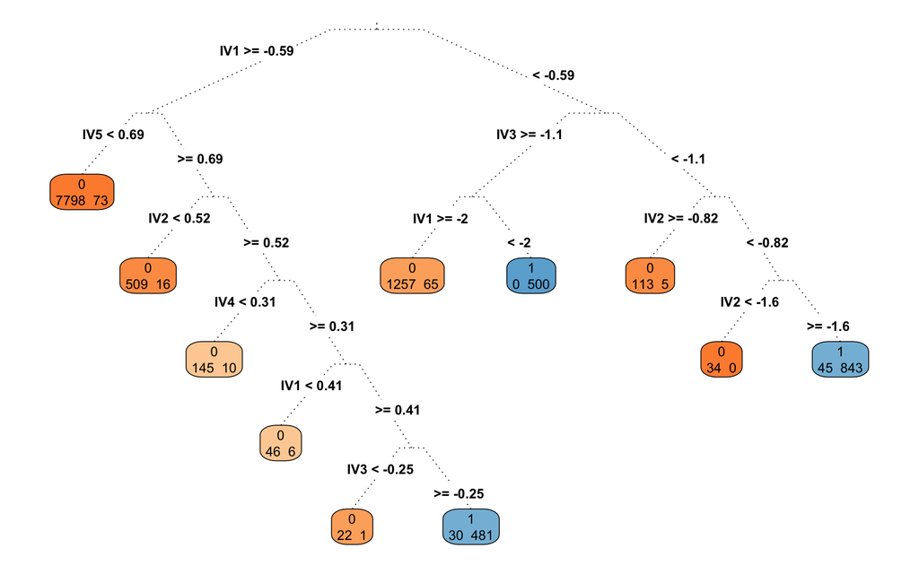

Based on our “small tree” we can make several observation regarding the churn of our employees. If a person has a very low satisfaction level of below and has a high number of projects he will most likely leave.If a person has a high level of satisfaction and spend little time at the company he is unlikely to leave.

Let’s look at the larger tree by changing the tree’s complexity control parameter. For example, this is how the tree would look like if we set `cp = 0.001`:

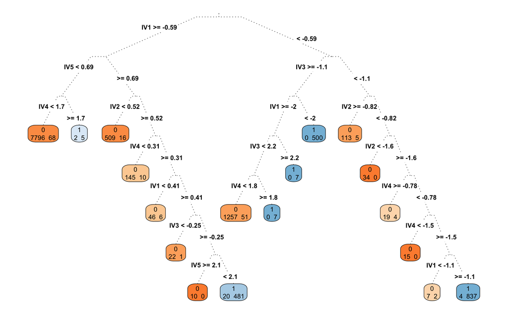

The purity of the leaf indicates the probability an observation which “reaches that leaf” belongs to a class. In our case, the probability of the employee leaving for the first few validation data observations, using the first CART above, is:

|  | Actual Class | Probability of Class 1 |
| --- | --- | --- |
| Obs 1 | 0 | 0.01 |
| Obs 2 | 1 | 0.95 |
| Obs 3 | 1 | 0.94 |
| Obs 4 | 1 | 1.00 |
| Obs 5 | 1 | 0.94 |
| Obs 6 | 1 | 0.95 |
| Obs 7 | 1 | 0.95 |
| Obs 8 | 1 | 1.00 |
| Obs 9 | 1 | 0.94 |
| Obs 10 | 1 | 0.94 |
| Obs 11 | 1 | 0.95 |
| Obs 12 | 1 | 0.95 |
| Obs 13 | 1 | 1.00 |
| Obs 14 | 1 | 0.94 |
| Obs 15 | 1 | 0.95 |
| Obs 16 | 1 | 0.95 |
| Obs 17 | 1 | 0.95 |
| Obs 18 | 1 | 0.95 |
| Obs 19 | 1 | 0.94 |
| Obs 20 | 1 | 0.95 |
| Obs 21 | 1 | 0.94 |
| Obs 22 | 1 | 1.00 |
| Obs 23 | 1 | 0.95 |
| Obs 24 | 1 | 1.00 |
| Obs 25 | 1 | 0.95 |

We would like to perform a classification analysis using logistic regression. This is the logistic regression parameters for our data:

|  | Estimate | Std. Error | z value | Pr(>\|z\|) |
| --- | --- | --- | --- | --- |
| (Intercept) | -1.5 | 0.1 | -14.7 | 0.0 |
| satisfaction_level | -1.0 | 0.0 | -33.2 | 0.0 |
| last_evaluation | 0.1 | 0.0 | 3.3 | 0.0 |
| number_project | -0.4 | 0.0 | -11.1 | 0.0 |
| average_montly_hours | 0.2 | 0.0 | 6.6 | 0.0 |
| time_spend_company | 0.4 | 0.0 | 15.1 | 0.0 |
| Work_accident | -1.4 | 0.1 | -13.0 | 0.0 |
| promotion_last_5years | -1.5 | 0.4 | -3.9 | 0.0 |
| Salary | -0.6 | 0.0 | -13.2 | 0.0 |
| Sales | 0.1 | 0.1 | 1.3 | 0.2 |
| Accounting | 0.1 | 0.2 | 0.5 | 0.6 |
| Hr | 0.2 | 0.2 | 1.5 | 0.1 |
| product_mng | 0.0 | 0.1 | 0.3 | 0.8 |
| technical | 0.2 | 0.1 | 1.4 | 0.2 |
| support | 0.2 | 0.1 | 1.7 | 0.1 |
| IT | 0.1 | 0.1 | 0.5 | 0.6 |
| RandD | -0.3 | 0.2 | -1.7 | 0.1 |

The probability our validation data belong to class 1 (the employee leaves) for the first few validation data observations, using the logistic regression above, is:

|  | Actual Class | Probability of Class 1 |
| --- | --- | --- |
| Obs 1 | 0 | 0.22 |
| Obs 2 | 1 | 0.42 |
| Obs 3 | 1 | 0.12 |
| Obs 4 | 1 | 0.42 |
| Obs 5 | 1 | 0.19 |
| Obs 6 | 1 | 0.43 |
| Obs 7 | 1 | 0.38 |
| Obs 8 | 1 | 0.61 |
| Obs 9 | 1 | 0.11 |
| Obs 10 | 1 | 0.11 |
| Obs 11 | 1 | 0.37 |
| Obs 12 | 1 | 0.33 |
| Obs 13 | 1 | 0.67 |
| Obs 14 | 1 | 0.17 |
| Obs 15 | 1 | 0.38 |
| Obs 16 | 1 | 0.42 |
| Obs 17 | 1 | 0.41 |
| Obs 18 | 1 | 0.35 |
| Obs 19 | 1 | 0.28 |
| Obs 20 | 1 | 0.03 |
| Obs 21 | 1 | 0.19 |
| Obs 22 | 1 | 0.65 |
| Obs 23 | 1 | 0.41 |
| Obs 24 | 1 | 0.70 |
| Obs 25 | 1 | 0.33 |

In our case, we can see the relative importance of the independent variables using the `variable.importance` of the CART trees (see `help(rpart.object)` in R) or the z-scores from the output of logistic regression. For easier visualization, we scale all values between -1 and 1 (the scaling is done for each method separately - note that CART does not provide the sign of the “coefficients”). From this table we can see the key drivers of the classification according to each of the methods we used here.

|  | CART 1 | CART 2 | Logistic Regr. |
| --- | --- | --- | --- |
| satisfaction_level | -1.00 | -1.00 | -1.00 |
| last_evaluation | 0.39 | 0.39 | 0.10 |
| number_project | -0.47 | -0.47 | -0.33 |
| average_montly_hours | 0.44 | 0.48 | 0.20 |
| time_spend_company | 0.32 | 0.34 | 0.45 |
| Work_accident | -0.02 | -0.02 | -0.39 |
| promotion_last_5years | 0.00 | 0.00 | -0.12 |
| Salary | 0.00 | 0.00 | -0.40 |
| Sales | 0.00 | 0.00 | 0.04 |
| Accounting | 0.00 | 0.00 | 0.02 |
| Hr | 0.00 | 0.00 | 0.05 |
| product_mng | 0.00 | 0.00 | 0.01 |
| technical | 0.00 | 0.00 | 0.04 |
| support | 0.00 | 0.00 | 0.05 |
| IT | 0.00 | 0.00 | 0.02 |
| RandD | 0.00 | 0.00 | -0.05 |